# Project Python Foundations: FoodHub Data Analysis

### Context

The number of restaurants in New York is increasing day by day. Lots of students and busy professionals rely on those restaurants due to their hectic lifestyles. Online food delivery service is a great option for them. It provides them with good food from their favorite restaurants. A food aggregator company FoodHub offers access to multiple restaurants through a single smartphone app.

The app allows the restaurants to receive a direct online order from a customer. The app assigns a delivery person from the company to pick up the order after it is confirmed by the restaurant. The delivery person then uses the map to reach the restaurant and waits for the food package. Once the food package is handed over to the delivery person, he/she confirms the pick-up in the app and travels to the customer's location to deliver the food. The delivery person confirms the drop-off in the app after delivering the food package to the customer. The customer can rate the order in the app. The food aggregator earns money by collecting a fixed margin of the delivery order from the restaurants.

### Objective

The food aggregator company has stored the data of the different orders made by the registered customers in their online portal. They want to analyze the data to get a fair idea about the demand of different restaurants which will help them in enhancing their customer experience. Suppose you are hired as a Data Scientist in this company and the Data Science team has shared some of the key questions that need to be answered. Perform the data analysis to find answers to these questions that will help the company to improve the business.

### Data Description

The data contains the different data related to a food order. The detailed data dictionary is given below.

### Data Dictionary

- order_id: Unique ID of the order
- customer_id: ID of the customer who ordered the food
- restaurant_name: Name of the restaurant
- cuisine_type: Cuisine ordered by the customer
- cost_of_the_order: Cost of the order
- day_of_the_week: Indicates whether the order is placed on a weekday or weekend (The weekday is from Monday to Friday and the weekend is Saturday and Sunday)
- rating: Rating given by the customer out of 5
- food_preparation_time: Time (in minutes) taken by the restaurant to prepare the food. This is calculated by taking the difference between the timestamps of the restaurant's order confirmation and the delivery person's pick-up confirmation.
- delivery_time: Time (in minutes) taken by the delivery person to deliver the food package. This is calculated by taking the difference between the timestamps of the delivery person's pick-up confirmation and drop-off information

### Let us start by importing the required libraries

```python
# Installing the libraries with the specified version.
!pip install numpy==1.25.2 pandas==1.5.3 matplotlib==3.7.1 seaborn==0.13.1 -q --user
```

**Note**: *After running the above cell, kindly restart the notebook kernel and run all cells sequentially from the start again.*

```python
# import libraries for data manipulation
import numpy as np
import pandas as pd
# import libraries for data visualization
import matplotlib.pyplot as plt
import seaborn as sns
```

### Understanding the structure of the data

```python
# uncomment and run the following lines for Google Colab
# from google.colab import drive
# drive.mount('/content/drive')
```

```python
# Write your code here to read the data
df = pd.read_csv("D:/IPYNB files of AIML/foodhub_order.csv")
```

```python
# Write your code here to view the first 5 rows
df.head(5)
```

|  | order_id | customer_id | restaurant_name | cuisine_type | cost_of_the_order | day_of_the_week | rating | food_preparation_time | delivery_time |
| --- | --- | --- | --- | --- | --- | --- | --- | --- | --- |
| 0 | 1477147 | 337525 | Hangawi | Korean | 30.75 | Weekend | Not given | 25 | 20 |
| 1 | 1477685 | 358141 | Blue Ribbon Sushi Izakaya | Japanese | 12.08 | Weekend | Not given | 25 | 23 |
| 2 | 1477070 | 66393 | Cafe Habana | Mexican | 12.23 | Weekday | 5 | 23 | 28 |
| 3 | 1477334 | 106968 | Blue Ribbon Fried Chicken | American | 29.20 | Weekend | 3 | 25 | 15 |
| 4 | 1478249 | 76942 | Dirty Bird to Go | American | 11.59 | Weekday | 4 | 25 | 24 |

### **Question 1:** How many rows and columns are present in the data? [0.5 mark]

```python
# Write your code here
# shape property is used to get the dimensions of the csv file and shape[0] is the number of rows and shape of [1] is the number of columns
shape = df.shape
print(f"Number of rows: {shape[0]}")
print(f"Number of columns: {shape[1]}")
```

```
Number of rows: 1898
Number of columns: 9
```

#### Observations:

### **Question 2:** What are the datatypes of the different columns in the dataset? (The info() function can be used) [0.5 mark]

```python
# Write your code here
# info function provides all the information of the data file, i.e the columns present and their datatypes.
df.info()
```

```
<class 'pandas.core.frame.DataFrame'>
RangeIndex: 1898 entries, 0 to 1897
Data columns (total 9 columns):
 #   Column                 Non-Null Count  Dtype
---  ------                 --------------  -----
 0   order_id               1898 non-null   int64
 1   customer_id            1898 non-null   int64
 2   restaurant_name        1898 non-null   object
 3   cuisine_type           1898 non-null   object
 4   cost_of_the_order      1898 non-null   float64
 5   day_of_the_week        1898 non-null   object
 6   rating                 1898 non-null   object
 7   food_preparation_time  1898 non-null   int64
 8   delivery_time          1898 non-null   int64
dtypes: float64(1), int64(4), object(4)
memory usage: 133.6+ KB
```

#### Observations:

### **Question 3:** Are there any missing values in the data? If yes, treat them using an appropriate method. [1 mark]

```python
# Write your code here
#Check the number of rows that have any missing values in them. We see that there are no missing values
# is null function is used to find if there are any null or missing values in the data.
df.isnull().sum()
# In the case that missing(NaN) values are present in the dataframe, we can use the following code:
# we cannot use df.fillna(0) as the data that is missing is filled with" not given " instead of NaN, hence the following code is to be used
df["rating"] = df["rating"].replace("Not given", 0)
```

#### Observations:

### **Question 4:** Check the statistical summary of the data. What is the minimum, average, and maximum time it takes for food to be prepared once an order is placed? [2 marks]

```python
# Write your code here
# min function is used to find the minimum, max function for the maximum value, and mean for the average value for the particular column in the data set
print(f'Minimum food preparation time: {df["food_preparation_time"].min()} minutes')
print(f'Maximum food preparation time: {df["food_preparation_time"].max()} minutes')
print(f'Average food preparation time: {round(df["food_preparation_time"].mean(),2)} minutes')
```

```
Minimum food preparation time: 20 minutes
Maximum food preparation time: 35 minutes
Average food preparation time: 27.37 minutes
```

#### Observations:

### **Question 5:** How many orders are not rated? [1 mark]

```python
# Write the code here
print(f'Number of unrated orders: {len(df.loc[df["rating"] == 0])}')
```

```
Number of unrated orders: 736
```

#### Observations:

### Exploratory Data Analysis (EDA)

### **Question 6:** Explore all the variables and provide observations on their distributions. (Generally, histograms, boxplots, countplots, etc. are used for univariate exploration.) [9 marks]

```python
# Convert rating to numeric
df['rating'] = pd.to_numeric(df['rating'], errors='coerce')

# Set the style of the visualizations
sns.set(style="whitegrid")
```

```python
# Function to plot histograms and boxplots for all numerical variables in the columns present in the data set
def plot_numerical_variable(column_name):
    fig, ax = plt.subplots(1, 2, figsize=(14, 5))

    # Histogram with color palette
    sns.histplot(df[column_name], bins=10, kde=True, ax=ax[0], color='dodgerblue')
    ax[0].set_title(f'Histogram of {column_name}')

    # Boxplot with color palette
    sns.boxplot(x=df[column_name], ax=ax[1], color='lightcoral')
    ax[1].set_title(f'Boxplot of {column_name}')

    plt.show()
```

```python
# Function to plot countplots for categorical variables
def plot_categorical_variable(column_name, threshold):
    plt.figure(figsize=(10, 5))

    # Create the countplot with color palette
    ax = sns.countplot(
        y=df[column_name],
        order=df[column_name].value_counts().index,
        palette='viridis'
    )

    # Get the y-tick labels
    # y-ticks determines the postions of the labels present
    #y-ticklables are the labels present in the y-axis
    # here only y-axis is formatted since it is a count plot and x-axis is only the count or frequecy of the column, where as the y is the column name
    y_ticks = ax.get_yticks()
    y_labels = [item.get_text() for item in ax.get_yticklabels()]

    # Modify y-tick labels to show every 10th label
    new_labels = [
        label if (i % threshold == 0) else ''
        for i, label in enumerate(y_labels)
    ]

    # Set the new y-tick labels
    ax.set_yticklabels(new_labels)

    plt.title(f'Countplot of {column_name}')
    plt.show()
```

```python
# Function to plot countplots for categorical variables (all labels)
def plot_categorical_variable2(column_name):
    plt.figure(figsize=(10, 5))

    # Create the countplot with color palette
    ax = sns.countplot(
        y=df[column_name],
        order=df[column_name].value_counts().index,
        palette='plasma'
    )

    plt.title(f'Countplot of {column_name}')
    plt.show()
```

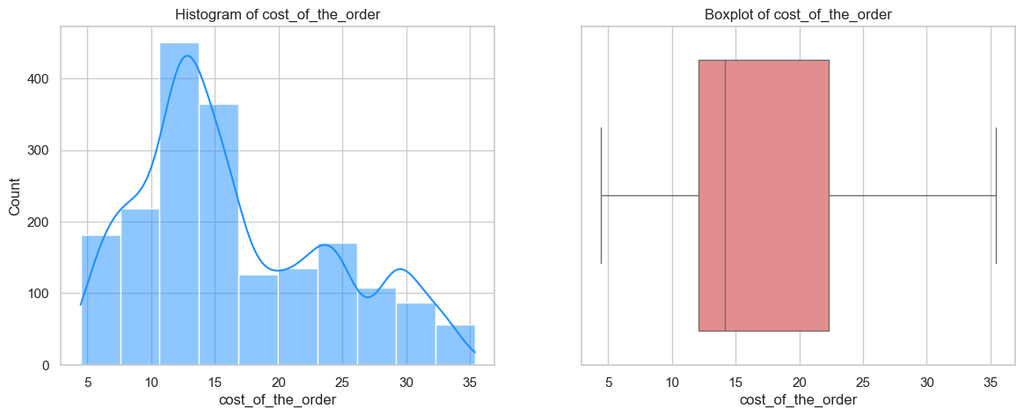

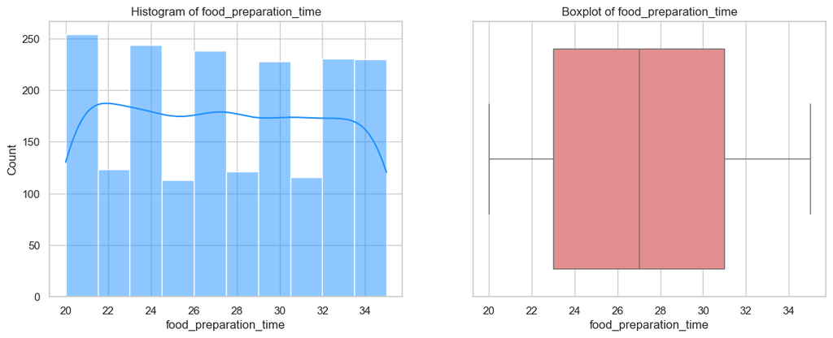

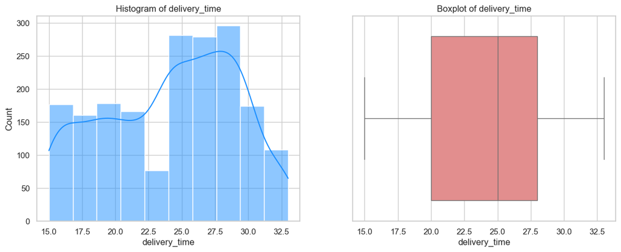

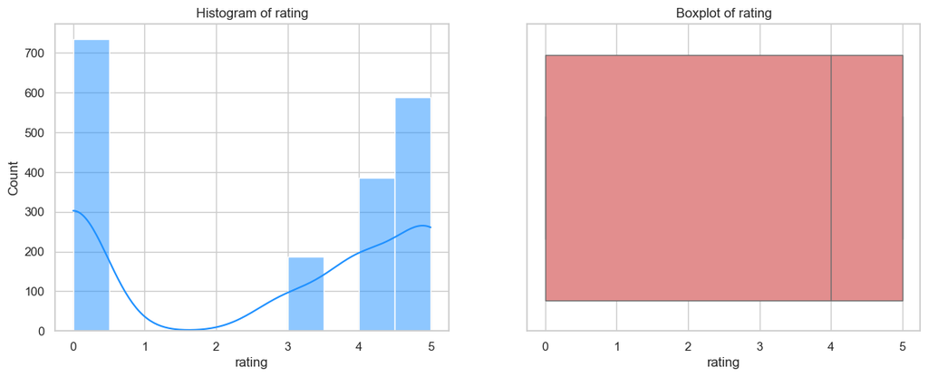

```python
# Numerical variables
numerical_columns = ['cost_of_the_order', 'food_preparation_time', 'delivery_time', 'rating']

for col in numerical_columns:
    plot_numerical_variable(col)
```

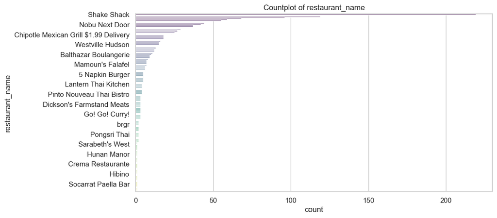

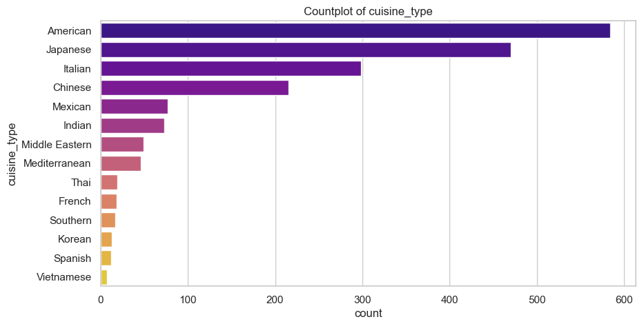

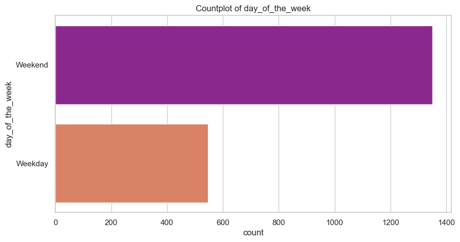

```python
import warnings
warnings.filterwarnings('ignore')

# Categorical variables
categorical_columns = ['restaurant_name', 'cuisine_type', 'day_of_the_week']

for col in categorical_columns:
    if col == "restaurant_name":
        plot_categorical_variable(col, 10)
    else:
        plot_categorical_variable2(col)
```

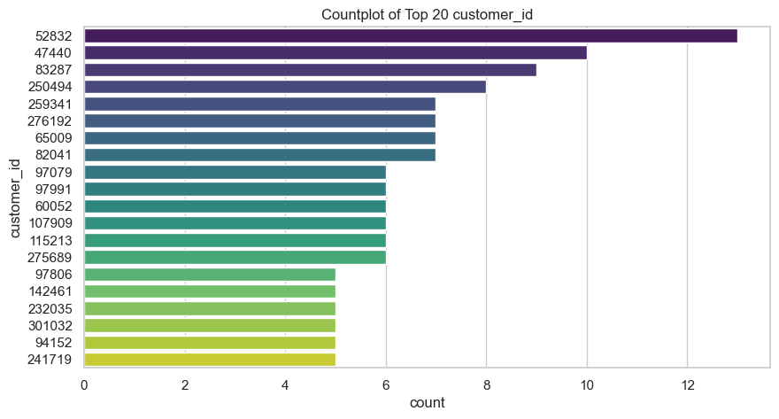

```python
def plot_top_n_customers(column_name, top_n=10):
    plt.figure(figsize=(10, 5))

    # Get the top N most frequent customer IDs( here N is 10 by default)
    top_n_values = df[column_name].value_counts().nlargest(top_n).index

    # Filter the DataFrame to include only these top N customers
    filtered_df = df[df[column_name].isin(top_n_values)]

    # Create the countplot
    ax = sns.countplot(
        y=filtered_df[column_name],
        order=filtered_df[column_name].value_counts().index,
        palette='viridis'
    )

    # Get the y-tick labels
    y_ticks = ax.get_yticks()
    y_labels = [item.get_text() for item in ax.get_yticklabels()]


    # Set the new y-tick labels
    ax.set_yticklabels(y_labels)

    plt.title(f'Countplot of Top {top_n} {column_name}')
    plt.show()

# Call the function with customer_id and display the top 20 customers
plot_top_n_customers('customer_id', top_n=20)
```

### **Question 7**: Which are the top 5 restaurants in terms of the number of orders received? [1 mark]

```python
# Write the code here
count_df = df.groupby(['restaurant_name'])['order_id'].count().reset_index(name='Count')
```

```python
count_df.sort_values(['Count'], ascending=False).head(5)
```

|  | restaurant_name | Count |
| --- | --- | --- |
| 136 | Shake Shack | 219 |
| 153 | The Meatball Shop | 132 |
| 21 | Blue Ribbon Sushi | 119 |
| 20 | Blue Ribbon Fried Chicken | 96 |
| 109 | Parm | 68 |

#### Observations:

### **Question 8**: Which is the most popular cuisine on weekends? [1 mark]

```python
# Write the code here
weekend_df = df[df["day_of_the_week"] == "Weekend"]
count_df = weekend_df.groupby(['restaurant_name'])['day_of_the_week'].count().reset_index(name='Number of orders')
print(f"Most popular on weekends: \n {count_df.sort_values(['Number of orders'], ascending=False, ignore_index=True).head(1)}")

weekday_df = df[df["day_of_the_week"] == "Weekday"]
count_df = weekday_df.groupby(['restaurant_name'])['day_of_the_week'].count().reset_index(name='Number of orders')
print(f"\nMost popular on weekdays: \n {count_df.sort_values(['Number of orders'], ascending=False, ignore_index=True).head(1)}")
```

```
Most popular on weekends:
   restaurant_name  Number of orders
0     Shake Shack               145

Most popular on weekdays:
   restaurant_name  Number of orders
0     Shake Shack                74
```

#### Observations:

### **Question 9**: What percentage of the orders cost more than 20 dollars? [2 marks]

```python
# Step 1: Note down the number of orders that are not null
total_number = len(df["cost_of_the_order"].notnull())
print(f'Total number of orders: {total_number}')

# Step 2: Count the number of orders that cost over 20 dollars
over_20 =len(df[df["cost_of_the_order"]>20])
print(f'Number of orders costing over $20 :{over_20}')

# Step 3: Calculate the percentage of orders over $20
print(f"Percentage of orders over $20: {round((over_20/total_number)*100,2)} %")
```

```
Total number of orders: 1898
Number of orders costing over $20 :555
Percentage of orders over $20: 29.24 %
```

#### Observations:

### **Question 10**: What is the mean order delivery time? [1 mark]

```python
# Write the code here
print(f'Mean order delivery time: {round(df["delivery_time"].mean(),2)} minutes')
```

```
Mean order delivery time: 24.16 minutes
```

#### Observations:

### **Question 11:** The company has decided to give 20% discount vouchers to the top 3 most frequent customers. Find the IDs of these customers and the number of orders they placed. [1 mark]

```python
customer_order_counts = df.groupby('customer_id').size().reset_index(name='order_count')
customer_order_counts.sort_values(by='order_count', ascending=False).head(3)
```

|  | customer_id | order_count |
| --- | --- | --- |
| 116 | 52832 | 13 |
| 84 | 47440 | 10 |
| 333 | 83287 | 9 |

#### Observations:

### **Question 12**: Perform a multivariate analysis to explore relationships between the important variables in the dataset. (It is a good idea to explore relations between numerical variables as well as relations between numerical and categorical variables) [10 marks]

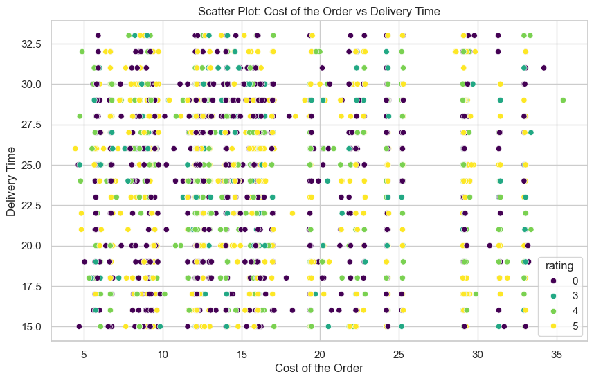

```python
# Scatter plot between cost_of_the_order and delivery_time
plt.figure(figsize=(10, 6))
sns.scatterplot(data=df, x='cost_of_the_order', y='delivery_time', hue='rating', palette='viridis')
plt.title('Scatter Plot: Cost of the Order vs Delivery Time')
plt.xlabel('Cost of the Order')
plt.ylabel('Delivery Time')
plt.show()
```

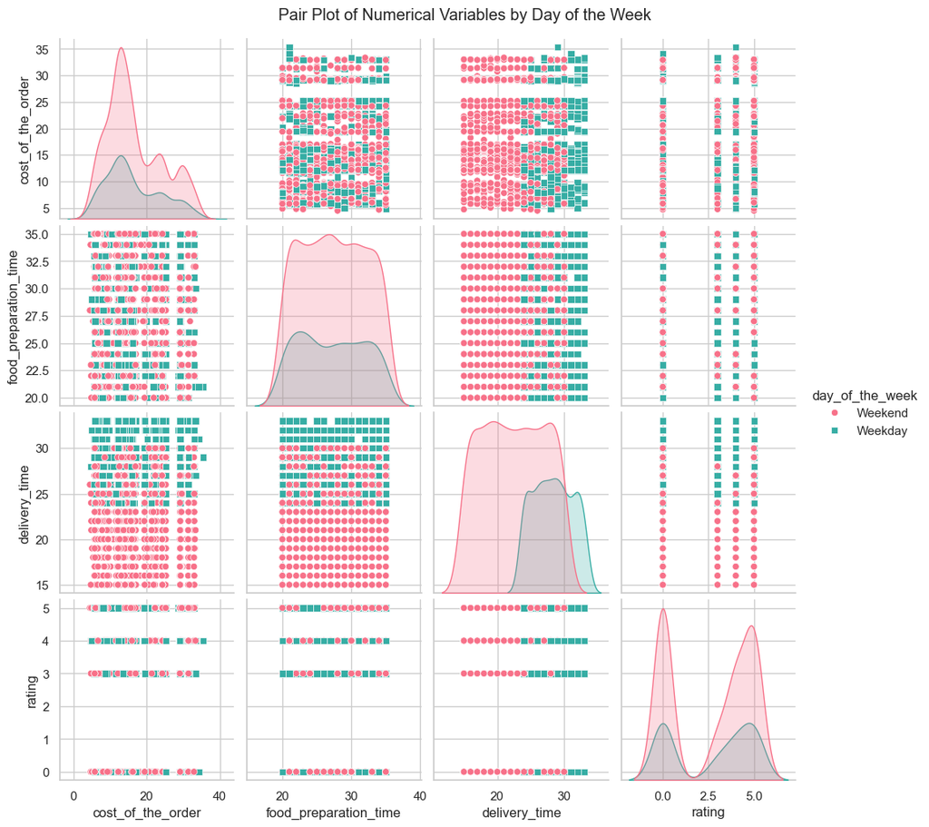

```python
# Number of unique values in 'day_of_the_week'
unique_days = df['day_of_the_week'].nunique()

# Pair plot with hue to explore relationships between multiple numerical variables
sns.pairplot(df[['cost_of_the_order', 'food_preparation_time', 'delivery_time', 'rating', 'day_of_the_week']],
             diag_kind="kde", hue="day_of_the_week", palette="husl", markers=["o", "s", "D", "X"][:unique_days])
plt.suptitle('Pair Plot of Numerical Variables by Day of the Week', y=1.02)
plt.show()
```

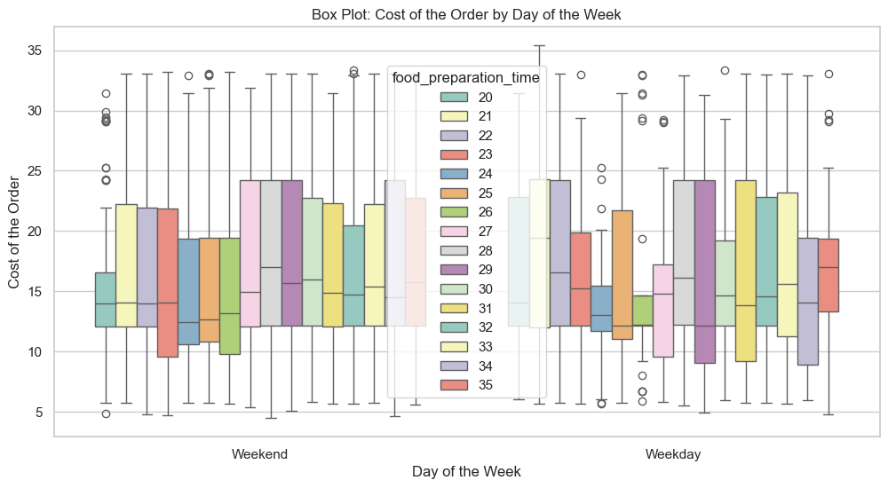

```python
# Box plot to show the distribution of cost_of_the_order for each day_of_the_week
plt.figure(figsize=(12, 6))
sns.boxplot(data=df, x='day_of_the_week', y='cost_of_the_order', hue = 'food_preparation_time',palette='Set3')
plt.title('Box Plot: Cost of the Order by Day of the Week')
plt.xlabel('Day of the Week')
plt.ylabel('Cost of the Order')
plt.show()
```

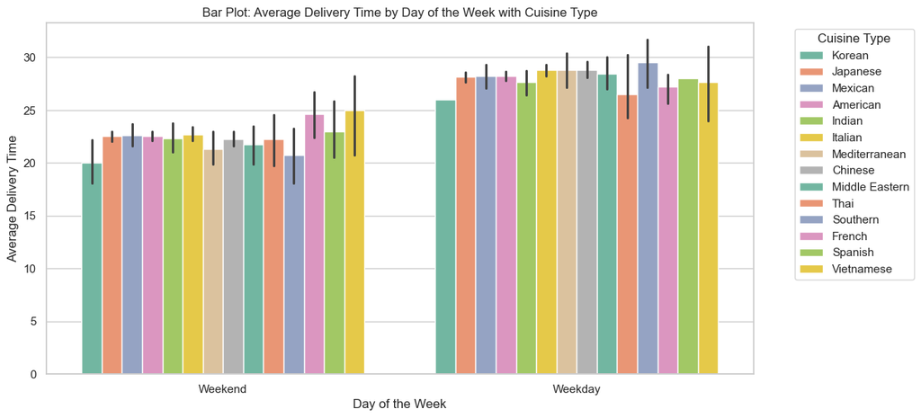

```python
# Bar plot to show the average delivery_time for each day_of_the_week with hue for cuisine_type
plt.figure(figsize=(12, 6))
sns.barplot(data=df, x='day_of_the_week', y='delivery_time', hue='cuisine_type', estimator=lambda x: sum(x) / len(x), palette='Set2')
plt.title('Bar Plot: Average Delivery Time by Day of the Week with Cuisine Type')
plt.xlabel('Day of the Week')
plt.ylabel('Average Delivery Time')
plt.legend(title='Cuisine Type', bbox_to_anchor=(1.05, 1), loc='upper left')
plt.show()
```

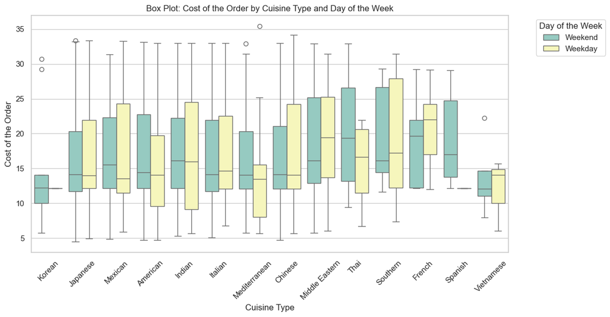

```python
# Box plot to show the distribution of cost_of_the_order for each cuisine_type with hue for day_of_the_week
plt.figure(figsize=(12, 6))
sns.boxplot(data=df, x='cuisine_type', y='cost_of_the_order', hue='day_of_the_week', palette='Set3')
plt.title('Box Plot: Cost of the Order by Cuisine Type and Day of the Week')
plt.xlabel('Cuisine Type')
plt.ylabel('Cost of the Order')
plt.xticks(rotation=45)
plt.legend(title='Day of the Week', bbox_to_anchor=(1.05, 1), loc='upper left')
plt.show()
```

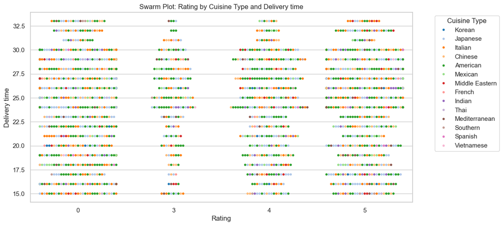

```python
# Swarm plot to show the distribution of rating for each cuisine_type with hue for day_of_the_week
plt.figure(figsize=(12, 6))
sns.swarmplot(data=df, x='rating', y='delivery_time', hue='cuisine_type', palette='tab20', size=4)
plt.title('Swarm Plot: Rating by Cuisine Type and Delivery time')
plt.xlabel('Rating')
plt.ylabel('Delivery time')
plt.legend(title='Cuisine Type', bbox_to_anchor=(1.05, 1), loc='upper left')
plt.show()
```

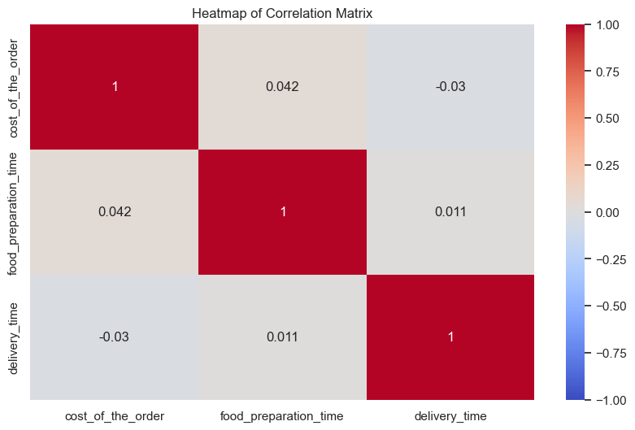

```python
# Calculate the correlation matrix
corr_matrix = df[['cost_of_the_order', 'food_preparation_time', 'delivery_time']].corr()

# Heatmap to visualize the correlation matrix
plt.figure(figsize=(10, 6))
sns.heatmap(corr_matrix, annot=True, cmap='coolwarm', vmin=-1, vmax=1)
plt.title('Heatmap of Correlation Matrix')
plt.show()
```

### **Question 13:** The company wants to provide a promotional offer in the advertisement of the restaurants. The condition to get the offer is that the restaurants must have a rating count of more than 50 and the average rating should be greater than 4. Find the restaurants fulfilling the criteria to get the promotional offer. [3 marks]

```python
df['rating'] = pd.to_numeric(df['rating'], errors='coerce')

# Drop rows with NaN values in the 'rating' column
df_rating = df.dropna(subset=['rating'])

# Group by restaurant_name to get the rating count and average rating
restaurant_ratings = df_rating.groupby('restaurant_name').agg(
    rating_count=('rating', 'size'),
    average_rating=('rating', 'mean')
).reset_index()

# Filter restaurants based on the conditions
eligible_restaurants = restaurant_ratings[
    (restaurant_ratings['rating_count'] > 50) &
    (restaurant_ratings['average_rating'] > 4)
]
eligible_restaurants.sort_values(by="rating_count", ascending=False)
```

|  | restaurant_name | rating_count | average_rating |
| --- | --- | --- | --- |

#### Observations:

### **Question 14:** The company charges the restaurant 25% on the orders having cost greater than 20 dollars and 15% on the orders having cost greater than 5 dollars. Find the net revenue generated by the company across all orders. [3 marks]

```python
def calculate_commission(cost):
    if cost > 20:
        return cost * 0.25
    elif cost > 5:
        return cost * 0.15
    else:
        return 0

# Apply the function to the 'cost_of_the_order' column to calculate the revenue for each order
df['revenue'] = df['cost_of_the_order'].apply(calculate_commission)

# Sum up the revenue to get the total net revenue
print(f"Total revenue generated: ${df['revenue'].sum()}")
```

```
Total revenue generated: $6166.303
```

#### Observations:

### **Question 15:** The company wants to analyze the total time required to deliver the food. What percentage of orders take more than 60 minutes to get delivered from the time the order is placed? (The food has to be prepared and then delivered.) [2 marks]

```python
df['total_time'] = df['food_preparation_time'] + df['delivery_time']

# Count the number of orders with total time greater than 60 minutes
orders_above_60_minutes = df[df['total_time'] > 60].shape[0]
print("Orders that take more than 60 minutes: ",orders_above_60_minutes)

# Calculate the total number of orders
total_orders = df.shape[0]
print("Total orders:",total_orders )

# Calculate the percentage of orders that take more than 60 minutes
percentage_above_60_minutes = (orders_above_60_minutes / total_orders) * 100

print(f"Percentage of orders that take more than 60 minutes to get delivered: {percentage_above_60_minutes:.2f}%")
```

```
Orders that take more than 60 minutes:  200
Total orders: 1898
Percentage of orders that take more than 60 minutes to get delivered: 10.54%
```

#### Observations:

### **Question 16:** The company wants to analyze the delivery time of the orders on weekdays and weekends. How does the mean delivery time vary during weekdays and weekends? [2 marks]

```python
df.groupby('day_of_the_week')['delivery_time'].mean().reset_index()
```

|  | day_of_the_week | delivery_time |
| --- | --- | --- |
| 0 | Weekday | 28.340037 |
| 1 | Weekend | 22.470022 |

#### Observations:

### Conclusion and Recommendations

### **Question 17:** What are your conclusions from the analysis? What recommendations would you like to share to help improve the business? (You can use cuisine type and feedback ratings to drive your business recommendations.) [6 marks]

# Conclusions:

This report provides a comprehensive analysis of FoodHub's performance metrics, focusing on aspects such as restaurant popularity, food preparation time, order costs, delivery efficiency, and customer satisfaction. The data highlights Shake Shack as the most popular restaurant, indicates consistent demand, and suggests areas for improvement in delivery times and customer engagement. Key findings and recommendations are presented to enhance service quality and customer satisfaction, supporting strategic business decisions for FoodHub.

## Restaurant Popularity and Demand

### Shake Shack's Dominance

Shake Shack emerges as the most popular restaurant during both weekdays and weekends. This consistent demand underscores the brand's strong market presence and customer preference.

## Average Food Preparation Time

### Preparation Time Analysis

The average food preparation time across all restaurants is approximately 27.37 minutes. This time frame aligns with industry standards, balancing the need for quality preparation with efficient service delivery.

### Correlation with Order Costs

A correlation coefficient of 0.042 indicates a very weak positive correlation between the cost of the order and food preparation time. This suggests that higher-priced orders take slightly longer to prepare, but the impact is negligible.

## Order Costs

### Distribution of Order Costs

Approximately 29.24% of orders cost over $20. This significant portion of high-cost orders reflects a customer base willing to pay for premium menu items, indicating potential for revenue growth through dynamic pricing strategies.

### Correlation with Delivery Time

The correlation coefficient of -0.03 between order cost and delivery time suggests a very weak negative correlation. This implies that higher-cost orders are slightly associated with shorter delivery times, but the effect is almost negligible.

## Delivery Times

Delivery time ranges from approximately 15 to 32.5 minutes. This suggests that most orders are delivered within this timeframe, regardless of the type of cuisine.

### General Delivery Efficiency

The mean order delivery time is 24.16 minutes. While generally acceptable, 10.54% of orders exceed 60 minutes, negatively impacting customer satisfaction.

### Correlation with Preparation Time

A correlation coefficient of 0.011 indicates an extremely weak positive correlation between food preparation time and delivery time, suggesting minimal impact of preparation duration on overall delivery efficiency.

## Customer Ratings

### Factors Influencing Ratings

The data does not show a clear correlation between customer ratings and variables like order cost or delivery time. This implies that other factors, such as food quality and customer service, play a more significant role in determining satisfaction.

## Cuisine Types

### Variety and Popularity

FoodHub offers a wide variety of cuisines, including American, Indian, Japanese, Mediterranean, Italian, Chinese, French, Mexican, Korean, Middle Eastern, Southern, Thai, Vietnamese, and Spanish. American cuisine is the most popular, followed by Japanese and Italian.

### Delivery Efficiency Across Cuisines

There is no significant difference in delivery times or customer ratings across different cuisine types, suggesting consistent delivery efficiency and satisfaction regardless of the cuisine.

## Delivery Time Distribution

### Distribution Range

Overall Trend: Despite the variations, the overall trend suggests that the average delivery time is under 35 minutes for all cuisine types on both weekdays and weekends. This indicates that the food aggregator company is maintaining a reasonable delivery time across all cuisines and days of the week.

In summary, the cost of the order, food preparation time, and delivery time are largely independent of each other according to this data. This could imply that the efficiency of the restaurant’s food preparation and the delivery service are not significantly impacted by the cost of the orders. However, it’s important to note that correlation does not imply causation, and these findings should be further investigated with more rigorous statistical testing.

While the swarm plot provides a useful overview of the distribution of customer ratings and delivery times across different cuisine types, it does not provide clear insights into the factors that influence these variables. Further analysis could involve exploring the relationship between these variables and other factors such as cost of the order, day of the week, and food preparation time. This would provide a more comprehensive understanding of the factors that influence customer satisfaction and help the company make data-driven decisions to improve their service.

This analysis can help the company in understanding the factors affecting their service and in making data-driven decisions to improve their business. They might focus on improving their app’s user interface or expanding their restaurant partnerships, as these areas are not directly tied to the cost of orders or delivery times. Consider conducting customer surveys to gather more data on customer preferences and satisfaction levels.

# Recommendations:

Improve Delivery Efficiency Promote High-Rated Restaurants Encourage Customer Ratings Implement Dynamic Pricing Enhance Customer Engagement

To enhance delivery efficiency, particularly for the 10.54% of orders taking over an hour, FoodHub should optimize delivery routes and increase delivery personnel during peak times. If a particular cuisine type consistently has longer delivery times, the company might investigate the reasons and work with the restaurants to improve their preparation or handling times. Understanding the difference in delivery times between weekdays and weekends can help in better planning and resource allocation.

To improve customer engagement, especially for those who order infrequently, FoodHub could conduct surveys or direct communication to understand their preferences and address any barriers to more frequent use. With 736 unrated orders, offering incentives like discounts or loyalty points for customer ratings can gather more data for service improvement.

Introducing dynamic pricing or premium menu items, given the significant portion of orders exceeding $20, can boost revenue and cater to customers willing to pay for premium experiences. Understanding the cost patterns can assist in making strategic decisions about restaurant partnerships, pricing strategies, and promotional offers. It can also help in predicting demand and managing resources effectively. For instance, if Japanese cuisine orders are typically higher-priced and popular over the weekend, the company might consider partnering with more Japanese restaurants or offering special deals to attract more customers.

For instance, they might focus on improving their app’s user interface or expanding their restaurant partnerships, as these areas are not directly tied to the cost of orders or delivery times. They could also consider conducting customer surveys to gather more data on customer preferences and satisfaction levels. This would provide a more holistic view of their service and help identify areas for improvement.

It might be useful to look at these correlations broken down by restaurant, cuisine type, or day of the week to see if there are any specific trends or patterns. It could also be beneficial to analyze the relationship between these variables and the customer ratings to understand the factors contributing to customer satisfaction.